# Data_Analysis_2

2024-03-15

```
## ──────────────────────────────────────────────────────── Delimiter: "," chr
## (2): hostName, device dbl (6): ...1, cycle, temperature, voltage, current,
## capacity dttm (1): timestamp
```

# Data Analysis 2

## Question 1: How often is a battery swapped out?

Original capacity time series for SPO2SENSOR devices for hostName: 44-4b-5d-01-04-21

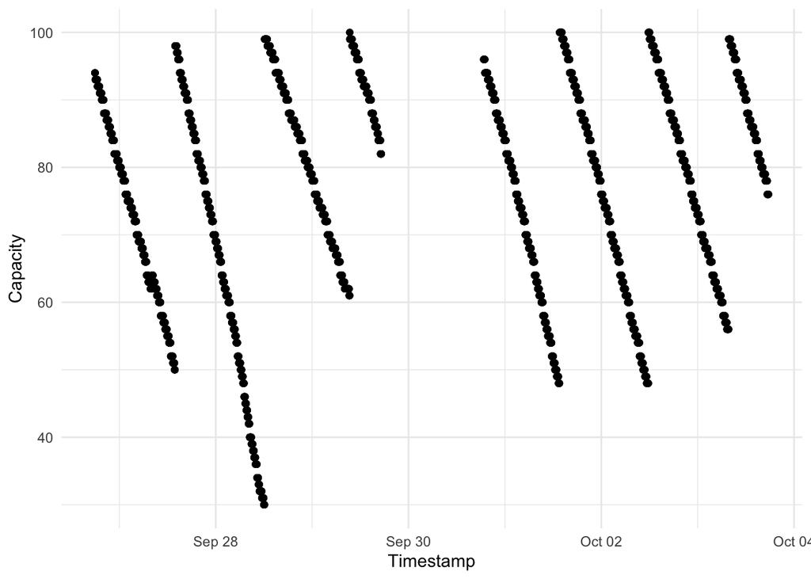

Clustering time series into periods of decreasing capacity with jumps in capacity no greater than 5. This is the results for SPO2SENSOR devices for hostName: 44-4b-5d-01-04-21:

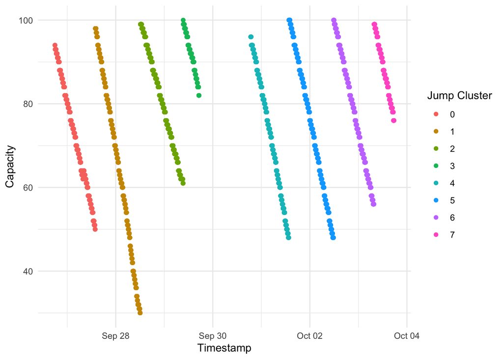

Identifying how long each SPO2SENSOR battery was used before being swapped out:

The average use time for SPO2SENSOR batteries before being swapped out for hostName: 44-4b-5d-01-04-21 is 17 hours.

[figure not shown]

### How long are SPO2 devices used before being swapped out?

For analysis purpose, not all hostNames will be used since some exhibit strange behavior for their SPO2SENSOR devices.

Acceptable for SPO2SENSOR Clustering Analysis: 44-4b-5d-01-04-29, 44-4b-5d-01-04-91, 44-4b-5d-01-04-09, 44-4b-5d-01-04-89, 44-4b-5d-01-04-21, 44-4b-5d-01-04-11, 44-4b-5d-01-04-31, 44-4b-5d-01-04-39

Strange Clustering - 44-4b-5d-01-04-01, 44-4b-5d-01-04-79, 44-4b-5d-01-04-81, 44-4b-5d-01-04-01, 44-4b-5d-01-04-19, 44-4b-5d-01-04-51 No SPO2SENSOR Devices - 44-4b-5d-01-04-a1, 44-4b-5d-01-04-41, 44-4b-5d-01-04-b1

```
## # A tibble: 1 × 4
##   hostName          jump_cluster  mins hours
##   <chr>                    <int> <dbl> <dbl>
## 1 44-4b-5d-01-04-11            3 1981.  33.0
```

```
## # A tibble: 1 × 4
##   hostName          jump_cluster  mins hours
##   <chr>                    <int> <dbl> <dbl>
## 1 44-4b-5d-01-04-29            7  280.  4.66
```

```
## [1] 19.79738
```

On average SPO2SENSOR batteries over all hosts are used for 19.79 hours before being swapped out. The longest use was 33 hours in host 44-4b-5d-01-04-11 and the shortest use was 4.66 hours in host 44-4b-5d-01-04-29.

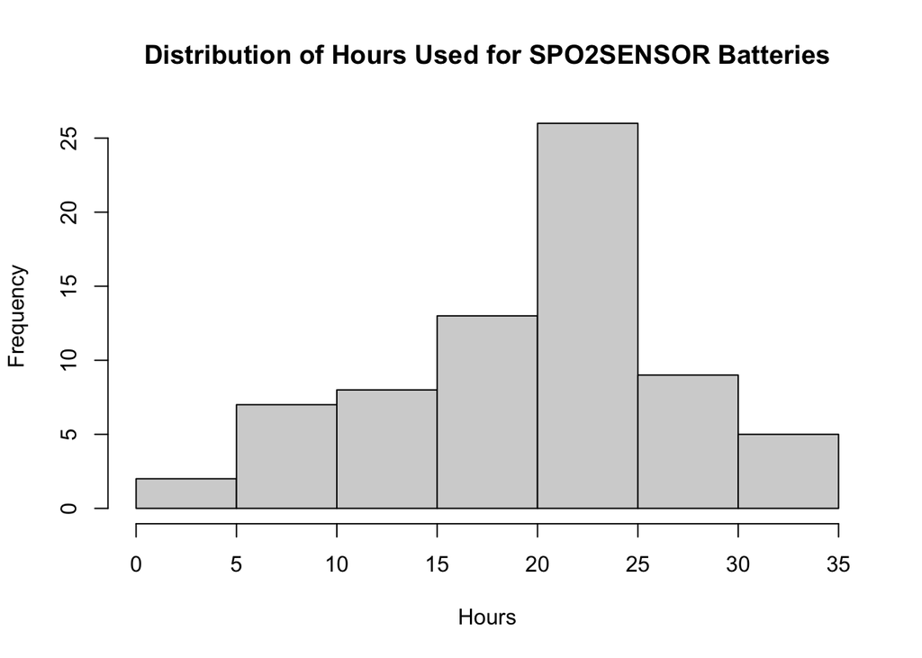

Most SPO2SENSOR batteries were used between 20-25 hours before being swapped out. Less than 5 SPO2SENSOR battery usages were between 0-5 hours.

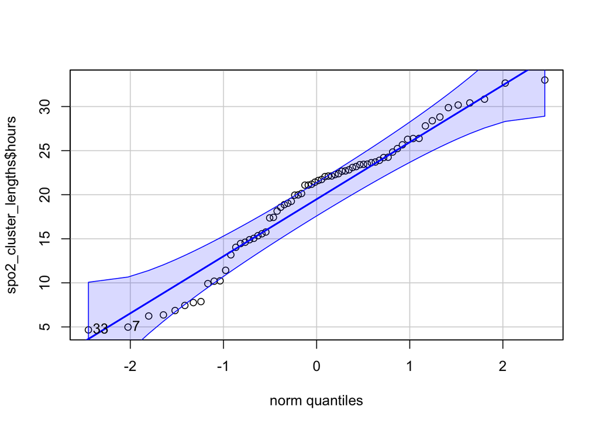

```
## [1] 33  7
```

The QQPlot does not strongly suggest that the SPO2SENSOR battery usages are normally distributed.

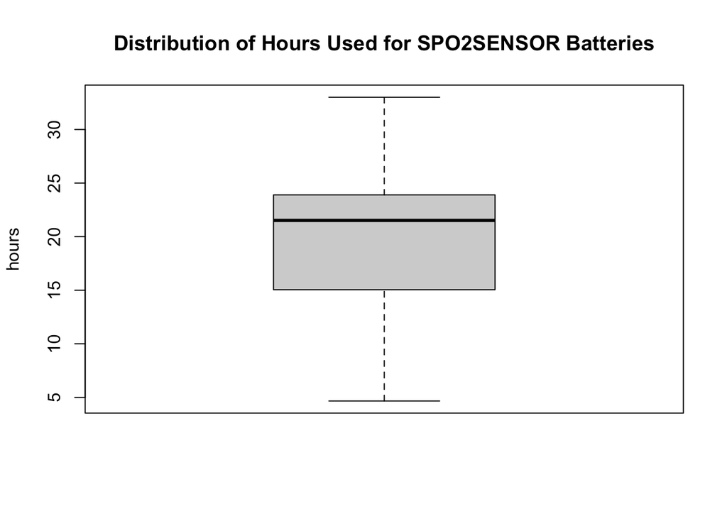

There are no outliers.

### How long are RESP devices used before being swapped out?

For analysis purpose, not all hostNames will be used since some exhibit strange behavior for their RESPSENSOR devices.

Included in Clustering: 44-4b-5d-01-04-29, 44-4b-5d-01-04-91, 44-4b-5d-01-04-09, 44-4b-5d-01-04-51, 44-4b-5d-01-04-21, 44-4b-5d-01-04-11, 44-4b-5d-01-04-81, 44-4b-5d-01-04-31, 44-4b-5d-01-04-39 Strange Clustering: 44-4b-5d-01-04-19, 44-4b-5d-01-04-79, 44-4b-5d-01-04-89, 44-4b-5d-01-04-01 No RESP devices: 44-4b-5d-01-04-41, 44-4b-5d-01-04-a1, 44-4b-5d-01-04-b1

```
## # A tibble: 1 × 4
##   hostName          jump_cluster  mins hours
##   <chr>                    <int> <dbl> <dbl>
## 1 44-4b-5d-01-04-11            3 1979.  33.0
```

```
## # A tibble: 1 × 4
##   hostName          jump_cluster  mins  hours
##   <chr>                    <int> <dbl>  <dbl>
## 1 44-4b-5d-01-04-51           15  1.02 0.0169
```

```
## [1] 19.21817
```

On average RESPSENSOR batteries over all hosts are used for 19.21 hours before being swapped out. The longest use was 33 hours in host 44-4b-5d-01-04-11 and the shortest use was 0.0169 hours in host 44-4b-5d-01-04-51.

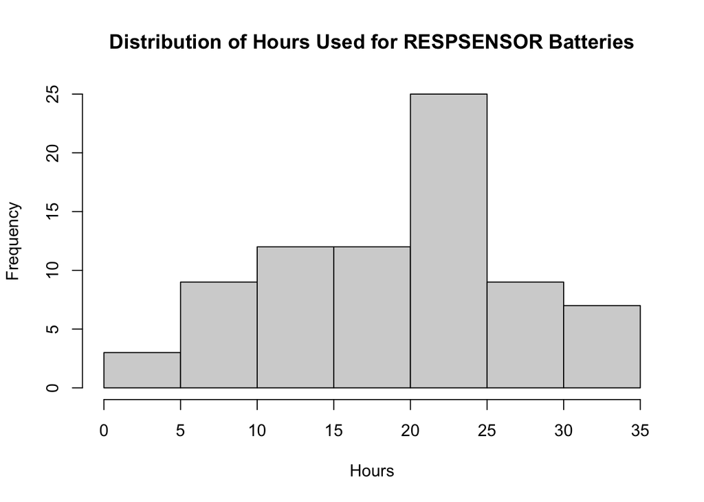

Most RESPSENSOR batteries were used between 20-25 hours before being swapped out. Less than 5 RESPSENSOR battery usages were between 0-5 hours.

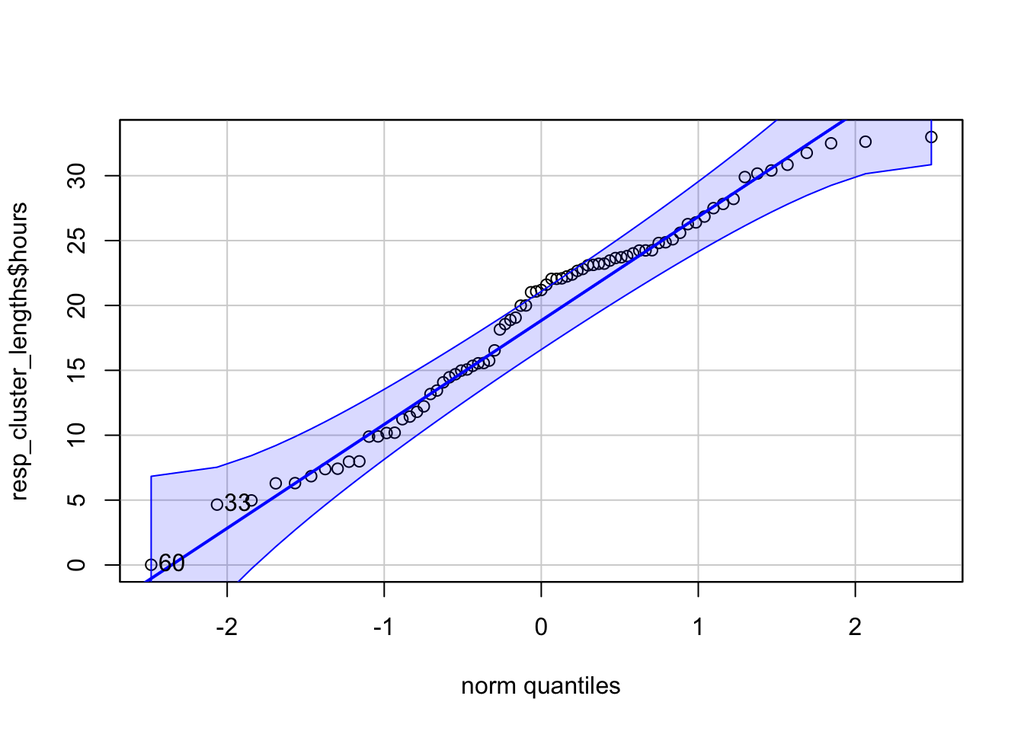

```
## [1] 60 33
```

The QQPlot does not strongly suggest that the RESPSENSOR battery usages are normally distributed.

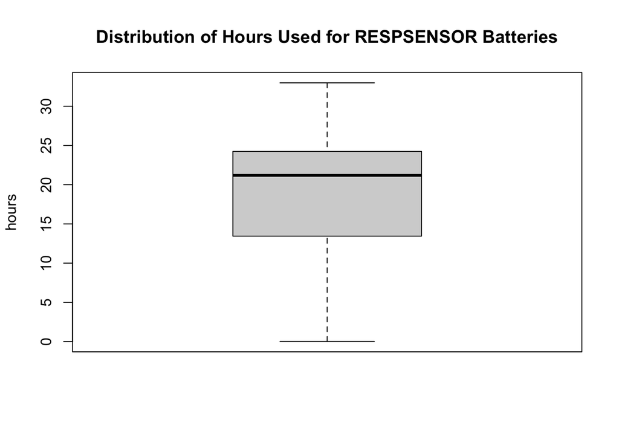

There are no outliers.

### Which Device is used for longer before being swapped?

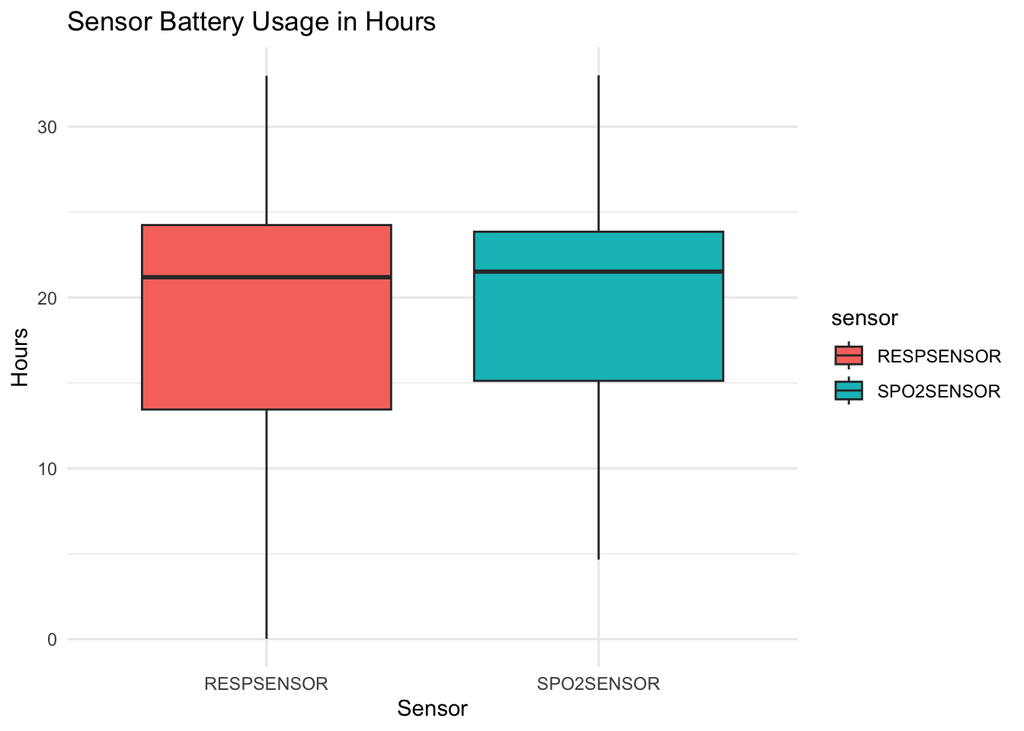

Permutation Test:

[output not shown]

[output cut: 192 more lines]

### Strange Clustering

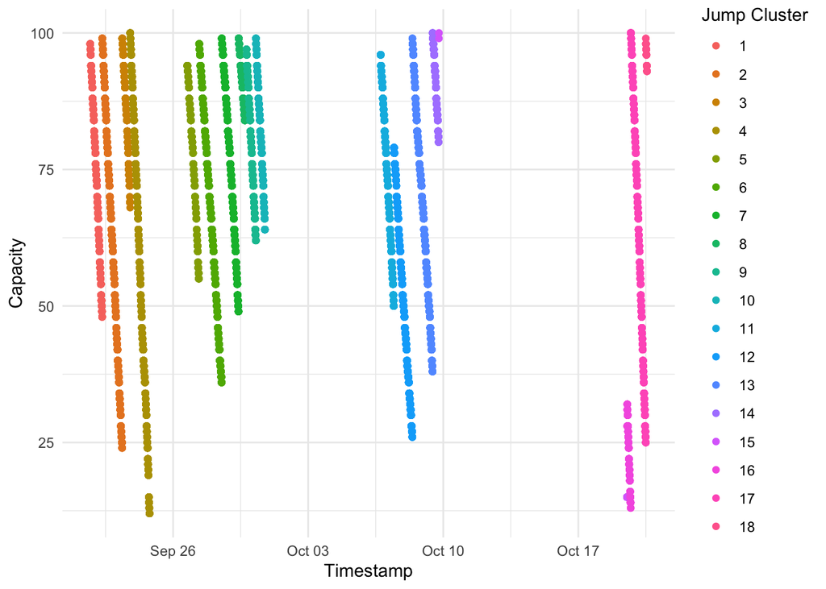